# State of the Union Addresses

Gina Reynolds, Susie Q., Johny J.

2/2/2019

# 1 Abstract

State of the Union addresses are a classic corpus for students of text analysis. To the author’s knowledge, less has been done to characterize the timing of addresses.[^1] In this paper you’ll see time-in-year by year plots and a model of the timing.

# 2 Introduction

# 3 Literature Review

The texts of the State of the Union addresses have been studied by scholars including Benoit, Munger and Spirling (2018); they offer an interesting analysis of State of the Union addresses by US presidents, noting that SOTU that are not delivered orally tend to use more complex language. There are several R text analysis packages (Silge and Robinson 2016; Benoit and Nulty 2016). These entries are included in the literature/bibliography.bib document that is referenced in the YMAL.

# 4 Theory and Hypotheses

This analysis was exploratory. It is well known that modern SOTU addresses are delivered early in the year. After plotting the data, what seemed to matter was year of delivery, and if the SOTU followed an election year. We tried to follow the advice in the e-book [The Fundamentals of Data Visualization](https://serialmentor.com/dataviz).

The principles in TFODV are listed in Table 4.1

Table 4.1: This is the caption for the table about data visualization categories from *“The Fundamentals of Data Visualization.”*

| Category | Description |
| --- | --- |
| Bad | Misrepresents data or confuse |
| Ugly | Not pleasing |
| Good | Not bad and not ugly |

# 5 Data

The corpus data was made available by on github.  
President in general give one SOTU address per year they serve as president but there are some exceptions as seen in table 5.1

Table 5.1: This table contains presidents and the number of SOTU that they have given

| President | Number of Addresses |
| --- | --- |
| Donald J. Trump | 3 |
| Barack Obama | 8 |
| George W. Bush | 8 |
| William J. Clinton | 8 |
| George Bush | 4 |
| Ronald Reagan | 8 |
| Jimmy Carter | 7 |
| Gerald R. Ford | 3 |
| Richard Nixon | 12 |
| Lyndon B. Johnson | 6 |
| John F. Kennedy | 3 |
| Dwight D. Eisenhower | 10 |
| Harry S. Truman | 8 |
| Franklin D. Roosevelt | 13 |

# 6 Analysis

## 6.1 Visualization of relationships

Here I show some of the relationships in the data visually:

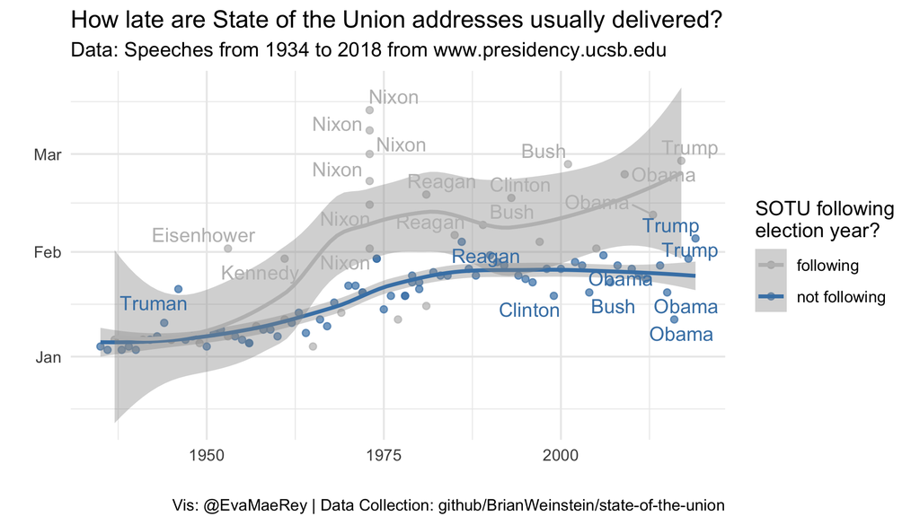

In figure 6.1 we use LOESS smoothing to summarize the relationship between year and time in year for the categories “following election year” and “not following”. In the linear modelling exercise below, we remove the 1973 cases, given that they are so unusual — in light of the Nixon impeachment, there were multiple SOTU’s delivered that year.

## 6.2 Modeling

We load the models that we’ve estimated and save out,then prepare the table using stargazer.

**Models of time elapsed in year before state of the union address Table 6.1:**

|  | Days elapsed since January 1st |  |  |  |
| --- | --- | --- | --- | --- |
|  | (1) | (2) | (3) | (4) |
| year | 0.401*** |  | 0.408*** | 0.320*** |
|  | (0.038) |  | (0.035) | (0.036) |
| post election |  | 7.700** | 8.654*** | -653.628*** |
|  |  | (2.991) | (1.894) | (139.861) |
| year*post election |  |  |  | 0.335*** |
|  |  |  |  | (0.071) |
| Constant | -773.950*** | 17.300*** | -789.534*** | -615.478*** |
|  | (75.412) | (1.511) | (68.468) | (71.731) |
| *N* | 94 | 94 | 94 | 94 |
| R<sup>2</sup> | 0.546 | 0.067 | 0.631 | 0.704 |
| Adjusted R<sup>2</sup> | 0.541 | 0.057 | 0.623 | 0.695 |
| Residual Std. Error | 8.821 (df = 92) | 12.644 (df = 92) | 7.999 (df = 91) | 7.196 (df = 90) |
| F Statistic | 110.654*** (df = 1; 92) | 6.628** (df = 1; 92) | 77.726*** (df = 2; 91) | 71.493*** (df = 3; 90) |
| *Notes:* | ***Significant at the 1 percent level. |  |  |  |
|  | **Significant at the 5 percent level. |  |  |  |
|  | *Significant at the 10 percent level. |  |  |  |

As you can see in the regression table 6.1, the R^2 for the full model with an interaction term is 0.704.

The full model formula with the interaction is:

$$DaysSinceJan1 = \beta_0 + \beta_1YEAR + B_2FollowingElection + B_3Year*FollowingElection + \epsilon$$

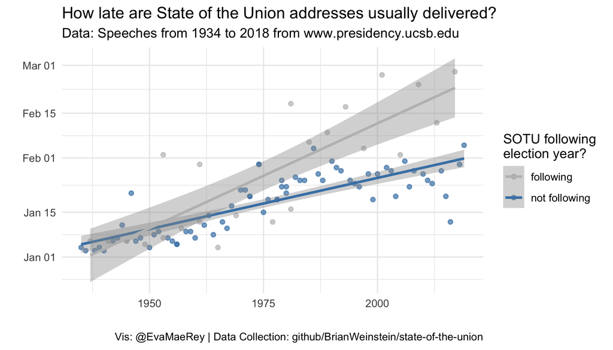

Note that the visualization of the linear models do not represent the full model with the interaction but rather independent models for each category “following”, “not following”, the default for ggplot2. Not going to worry about this.

# 7 Conclusion

# 8 References

Benoit, Kenneth, Kevin Munger, and Arthur Spirling. 2018. “Measuring and Explaining Political Sophistication Through Textual Complexity.” *Available at SSRN 3062061*.

Benoit, Kenneth, and Paul Nulty. 2016. “Quanteda: Quantitative Analysis of Textual Data.” *R Package Version 0.9* 8.

Silge, Julia, and David Robinson. 2016. “Tidytext: Text Mining and Analysis Using Tidy Data Principles in R.” *The Journal of Open Source Software* 1 (3): 37.